# FISH 558 Homework 4

Dan Ovando

October 31, 2015

## Model

Our goal for this assignment is to fit a Bayesian hierarchechal model to data of counts of mosquitoes at various distances along 20 different streams. The heirarchechal nature of the model works as follow. At the top level, we put priors on $\mu_{F}$ (the expected count at the rivermouth of stream 1) and $\mu_{L}$ (the expected count at the rivermouth of stream 20), and $\overline(\alpha)$ (the population mean of the rate of change in mosquitoe counts with density), as well as their associated variances. At the next level, these parameters are used to estimate stream-specific values of $\mu_{i}$ and $\alpha_{i}$. Moving down, we then estimate counts at distance *j*, and finally estimate the likelihood of the data using the estimated counts and the observed counts.

## Data

The data are shown in Fig.1. We see a broad trend of roughly exponential growth in mosquitoe counts as a function of distance upstream.

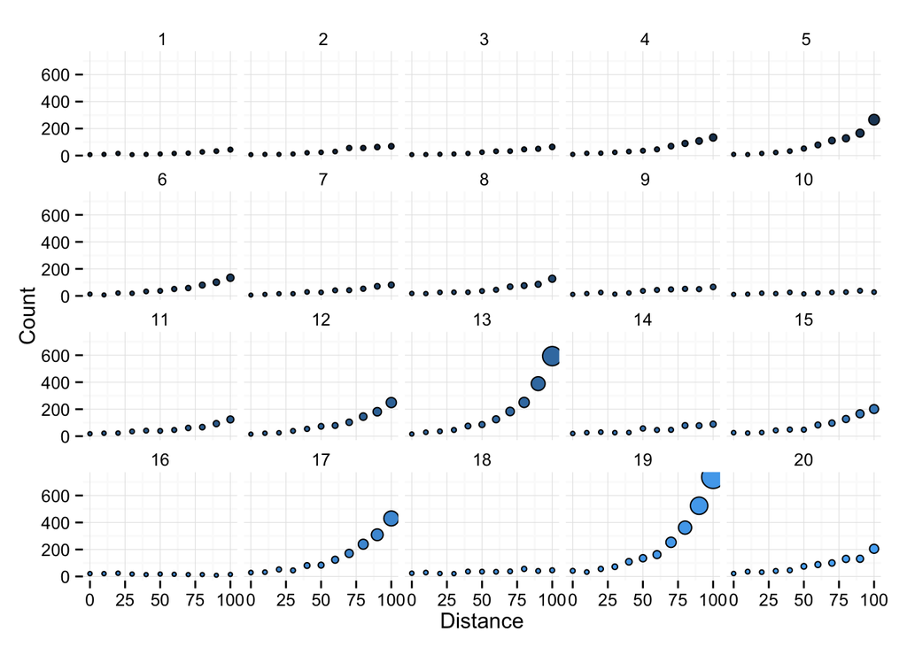

## The likelihoods

The posterior of any cycle in our MCMC chain is divided into the likelihood of the data and prior probabilities.

The data are poisson distributed, so the likelihood is given as the log of the likelihood of the observed counts at stream *i* at distance *j* if they came from a poisson distribution with mean $\mu_{i,j}$

Working our way from bottom to top in the priors, the likelood of a given value of $\mu_{i}$ is calculated from a normal distribution with mean $\mu_{f} + \frac{(\mu_{l} - \mu_{f}) - (i - 1)}{(20 - 1)}$ and standard deviation $\sigma_{\mu}$.

The prior probability of a given value of $\alpha_{i}$ is also calculated from a normal distribution, with mean $\overline{\alpha}$ and standard deviation $\sigma_{\alpha}$.

The hyper-prior probability of given values of $\mu_{f}$, $\mu_{L}$, and $\overline{\alpha}$ are assumed uniform. Since we know that $\mu$ cannot be negative (as much as we’d all love negative mosquitoes), we define the interval of the $\mu_{f/L}$ hyperpriors as U ~[0,Inf]. $\overline{\alpha}$ is drawn from U ~[-Inf,Inf].

The hyper-prior probability of given values of $\sigma_{\mu}$ and $\sigma_{\alpha}$ are assumed normal with mean 1 and .01 respectively, and standard deviations of 0.1

The posterior probability of a given cycle *c* of an MCMC chain is then given as

$Posterior_{c} = \sum_{i} \sum_{j} dpois(count_{i,j},\mu_{c,i,j}, log = T) + \sum_{i} dnorm(\mu_{c,i},f(uf,ul,i), \sigma_{\mu}, log = T) + \sum_{i} dnorm(\alpha_{c,i},\overline{\alpha},\sigma_{\alpha}, log = T) + dnorm(\sigma_{\mu},1,.1, log = T) + dnorm(\sigma_{\alpha},.01,.1, log = T) + dunif(\mu_{f},0,Inf, log = T) + dunif(\mu_{L},0,Inf, log = T)$

## Results

Histograms of the 45 posteriors estimated by our model are shown in Fig.2.

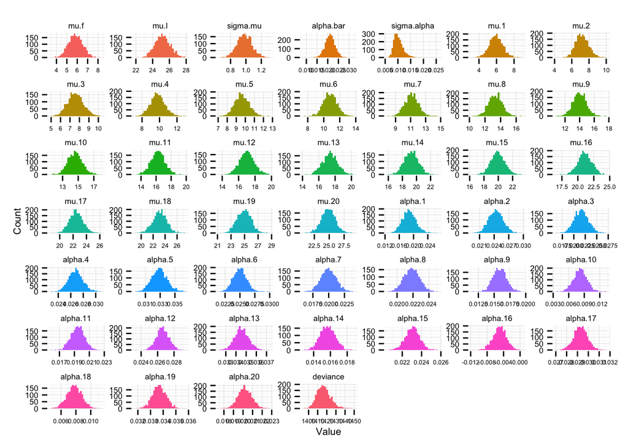

Examining model diagnostics, we see that $\alpha_{i}$ and $\mu_{i}$ are highly negatively correlated, meaning that the streams with the highest expected counts at the rivermouth tend to exhibit the lowest rate of change in expected counts as one moves upstream (Fig.3). There is the potential for some confounding effects between these two parameters thsn.

We seem some evidence that that $\alpha_{i}$ and $\mu_{i}$ are positively correalted with themselves in space (meaning that streams with high that $\alpha_{i}$ or $\mu_{i}$’s show some tendency to be near streams with high $\alpha_{i}$’s and $\mu_{i}$’s).

$\mu_{L}$ and $\mu_{F}$ are highly negatively correlated with each other as well, and both show some evidence of being negatively correlated with $\alpha$.

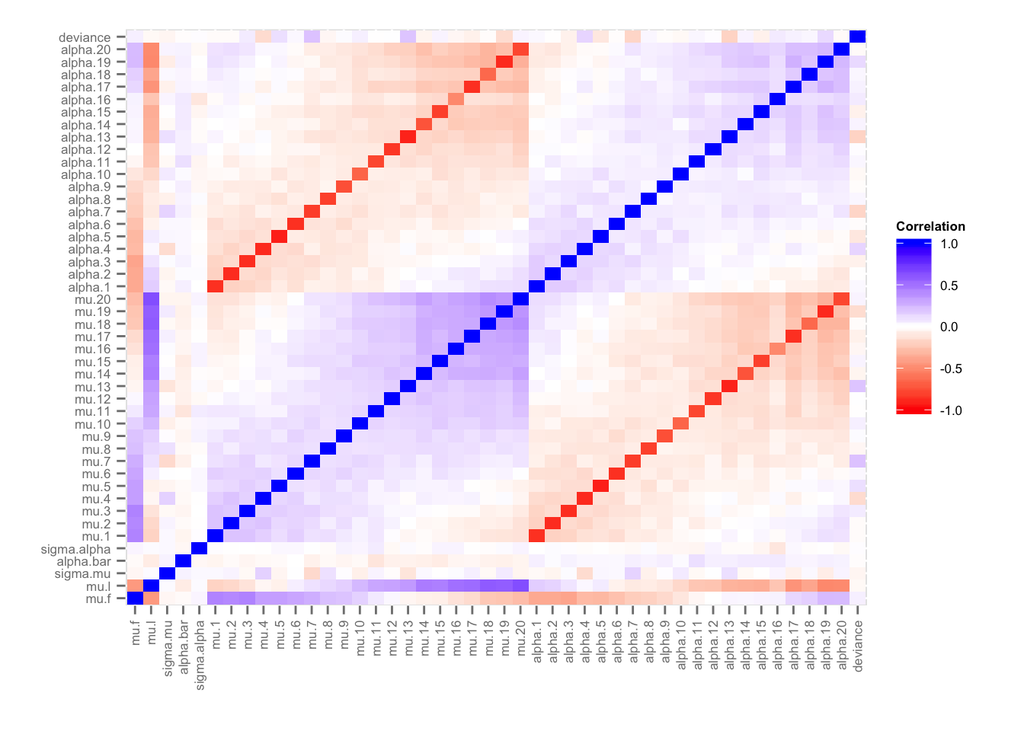

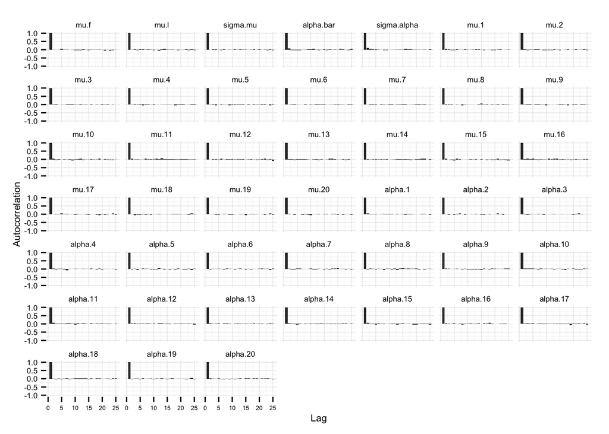

We use partial chains, the Gweke stastic, the Gelman-Rubin statistic, and cross-chain comparison to verify the stability of our MCMC chain.

For the paritial chain analysis, we compare the posterior densities of our parameters from the full chain to the posterior densities using only the last 10% of the chain. Post thinning and burn-in, our MCMC chain, and the associated posterior distributions, should not be still “evolving” over cycles. If it were, we might expect to see that the posteriors from the partial chain differ substantially from the broader chain. Our results show that the posterior densities from the complete and partial chains are nearly identical, providing evidence that our chain is stable.

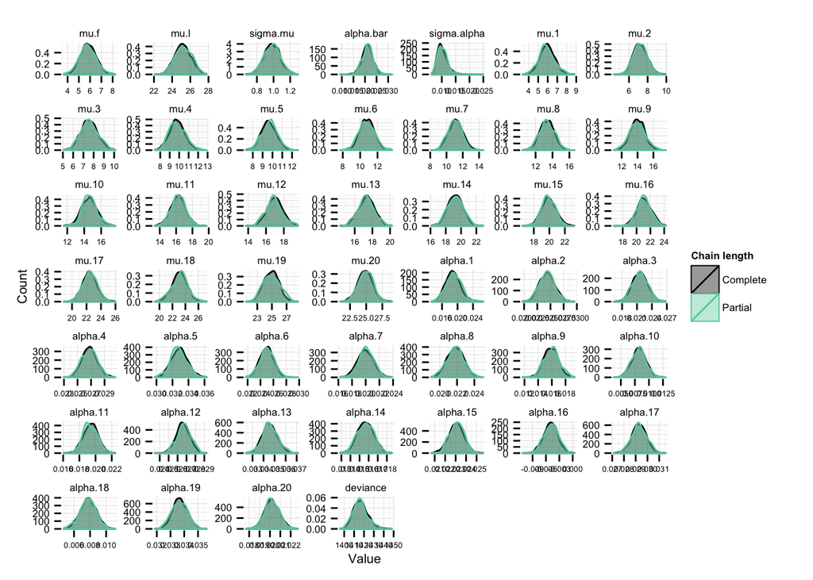

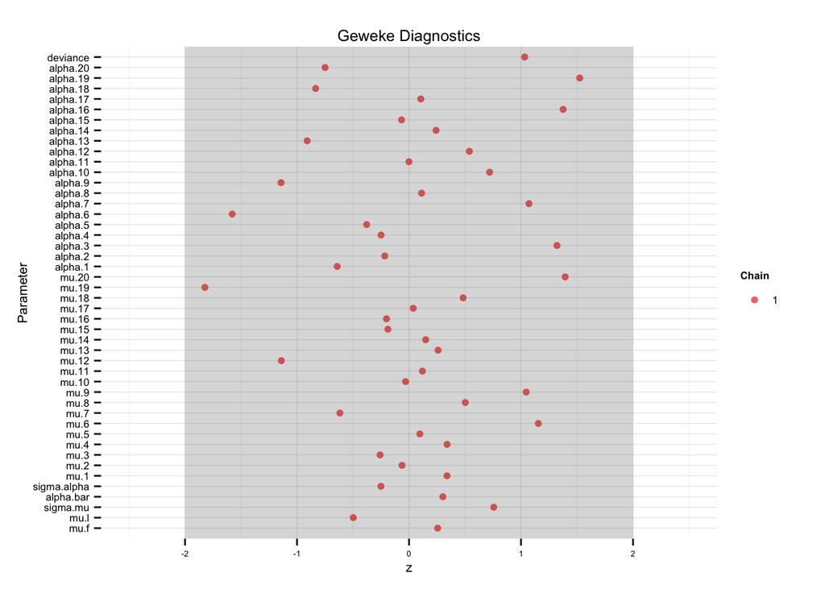

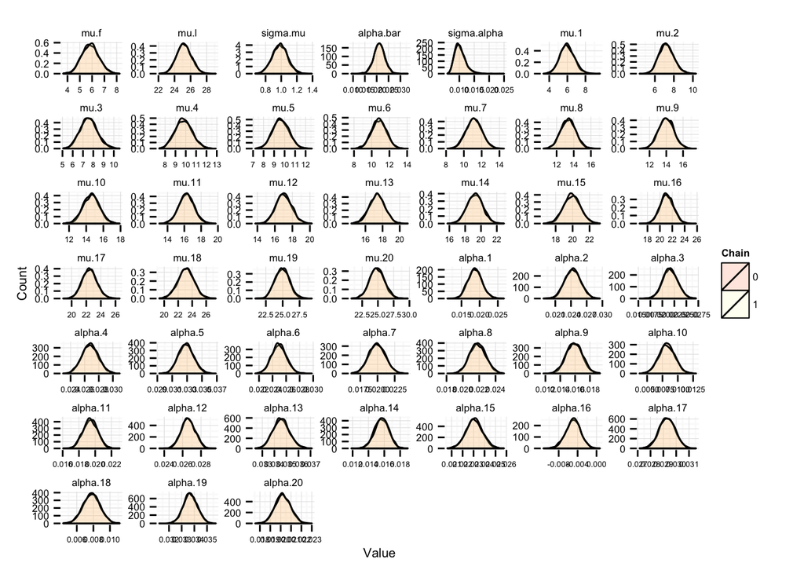

For the Gelman-Rubin test, we calculate the deviance for each cycle of the chain as $-2*LL$, where *LL* is the log-likelihood of the observed vs. predicted ($\mu_{i,j}$) counts. We then calculate *W* as the mean of the variance of the deviance in each chain, and *B* as the variance of the mean of the deviance in each chain, and calculate the *R* statistic through the aproximation $\frac{B + W}{W}$. Our resulting value is *R* = 1, suggesting that our chains have in fact converged.

### Decision Guidance

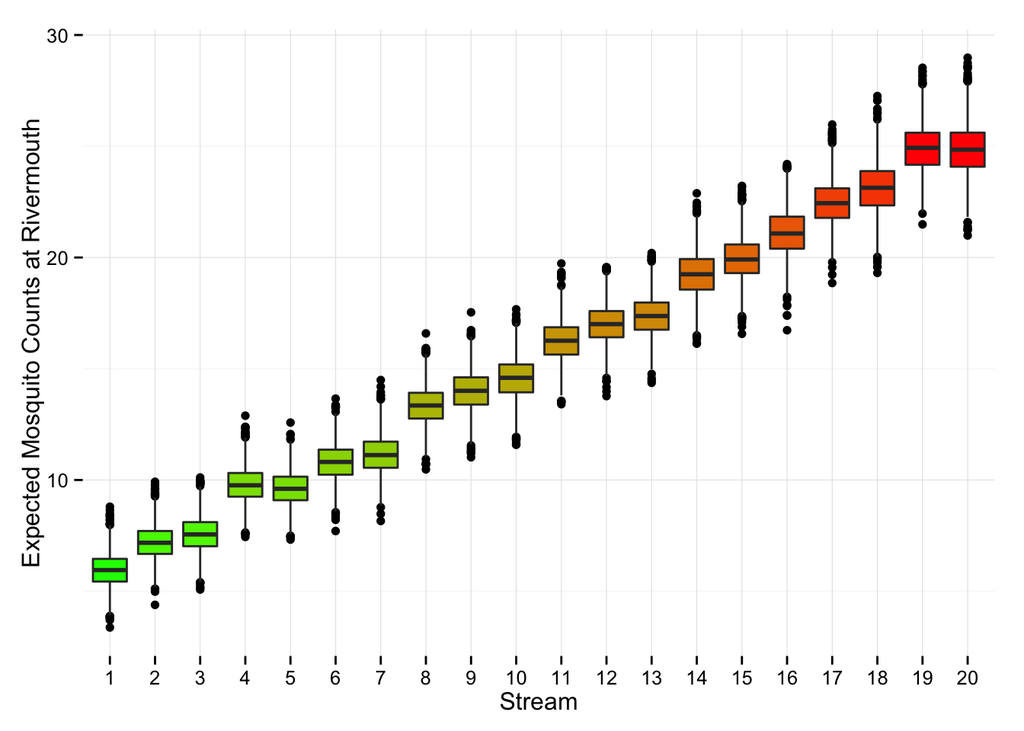

## Part 2

Our hypothetical surfer has now decided to go on a hike up stream #12 (latitude 12) since it has gone flat and he is bored, and wants to stop for lunch 15km up from the rivermouth. However, he is once again worried about mosquitoes, and so wants to know the predicted counts of mosquitoes at this site. Unfortuantely, we don’t ahve data for this 15km site, so we have to use a posterior predictive distribution. To obtain model estiamtes of predicted counts 15km’s up stream 12, we first draw all values from *C* retained cycles for $\mu_{c,i = 12}$ and $\alpha_{c,i = 12}$ from the posterior of our model. We then use these to estimate the expected count 15km up stream 12 per $\mu_{c,i = 12,j = 15} = \mu_{c,i = 12}e^{\alpha_{c,i = 12}*15}$.

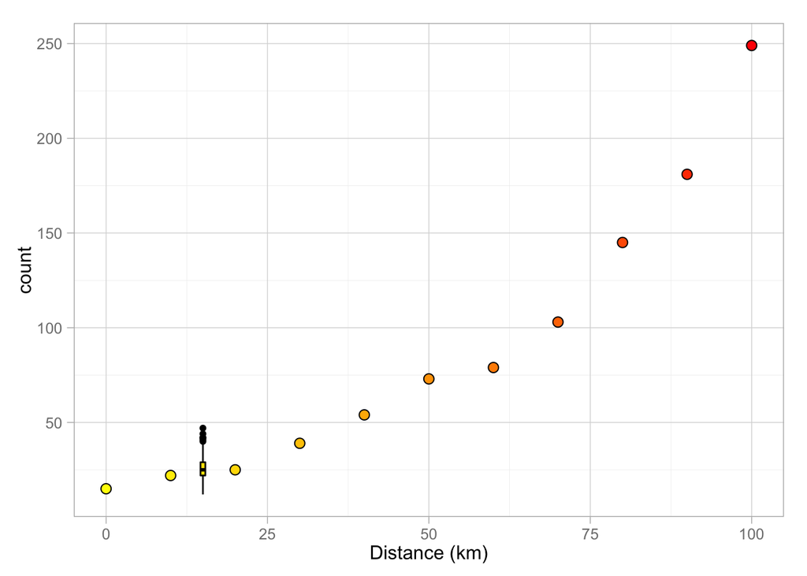

## Part 3

Lastly, our surfer might wonder whether this model really is a good predictor of mosquito counts. To address this concern, we compare the posterior predictive distribution of counts along stream 7 to teh observed counts. The methods are the same as in Part 2, except we now repeat the exercise for each distance observed in the data. We can then compare the predicted posterior distribtuions to the observed data.

We see that all of the observed counts fall within the 95% credibility interval of the posterior predictive distributions. However, we see some indication that our model does not fit the data as well at low counts (near the rivermouth), especially when the observed counts near 0. On the whole our model appears to capture the broad trend in mosquito counts well, but is not particularly precise, especially at low counts. The model certainly appears adequate at capturing the relative magnitude and trends in mosquito counts, but its performance suffers closer to the rivermouth of stream 7, where the observed counts are closer to zero.

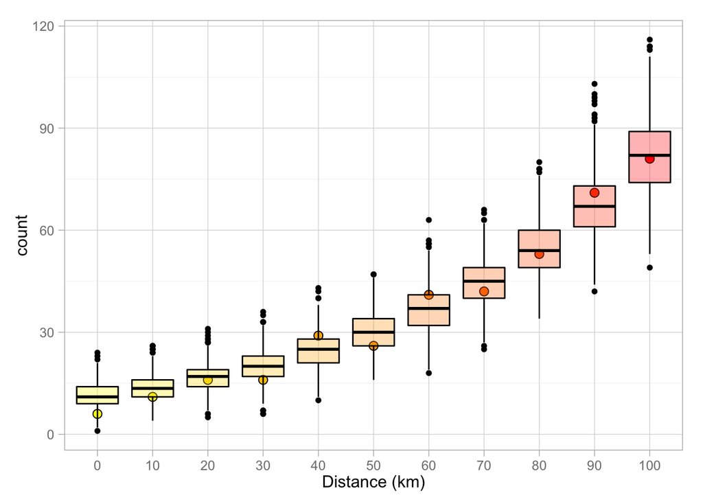